# GECO Philippines SARS-CoV-2 Situation Report - 2021-11-17

$~$

## Outline

$~$

$~$

## SARS-CoV-2 variant summary

$~$

| WHO label | Pango lineage | Classification | New from last report | Cumulative | Last 2 months (%) |
| --- | --- | --- | --- | --- | --- |
| Alpha | B.1.1.7/Q.x | VOC | - | 2748 | 12.973921 |
| Beta | B.1.351.x | VOC | - | 3204 | 13.894368 |
| Delta | B.1.617.2/AY.x | VOC | - | 3222 | 68.376068 |
| Eta | B.1.525 | VUM | - | 8 | 0.000000 |
| Gamma | P.1 | VOC | - | 6 | 0.000000 |
| Mu | B.1.621 | VOI | - | 1 | 0.000000 |
| Theta | P.3 | VUM | - | 517 | 4.076266 |

**Table 1.** Number of sequences available in Philippine.

$~$

[interactive chart not shown]

**Figure 1.** Temporal frequencies of SARS-CoV-2 lineages defined by Pango lineage.

$~$ $~$

## SARS-CoV-2 variants by administrative region

$~$

| Region | New from last report | Dominant variant last 2 month | Cumulative |
| --- | --- | --- | --- |
| National Capital Region | - | Delta | 3931 |
| Calabarzon | - | Delta | 1972 |
| Mimaropa | - | Delta | 332 |
| Zamboanga Peninsula | - | Delta | 417 |
| Central Visayas | - | Delta | 595 |
| Northern Mindanao | - | Delta | 325 |
| Cordillera Administrative Region | - | Delta | 747 |
| Central Luzon | - | Delta | 965 |
| Davao Region | - | Beta | 730 |
| Western Visayas | - | Delta | 498 |

[output cut: 7 more lines]

**Table 2.** Number of sequences in Philippine by region.

$~$

[interactive chart not shown]

**Figure 2.** Proportion of Pango lineage by region in the Philippines.

$~$ $~$

## SARS-CoV-2 sequencing in the Philippines

$~$

### Total number of SARS-CoV-2 sequences in the Philippines: **12804**

### GECO Project: **350**

$~$

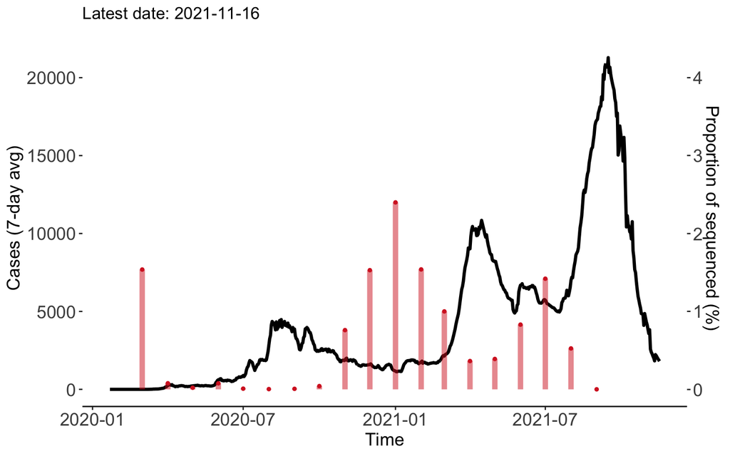

**Figure 3.** Number of COVID-19 cases and the proportion of sequenced samples in the Philippines. The black line indicates the mean cases in a 7 days window, whereas the red bars indicate the percentage of sequenced sample among cases in a month. The proportions in January and February, 2020 were discarded as they were outliers

$~$

## Rt of SARS-CoV-2 in the Philippines

$~$

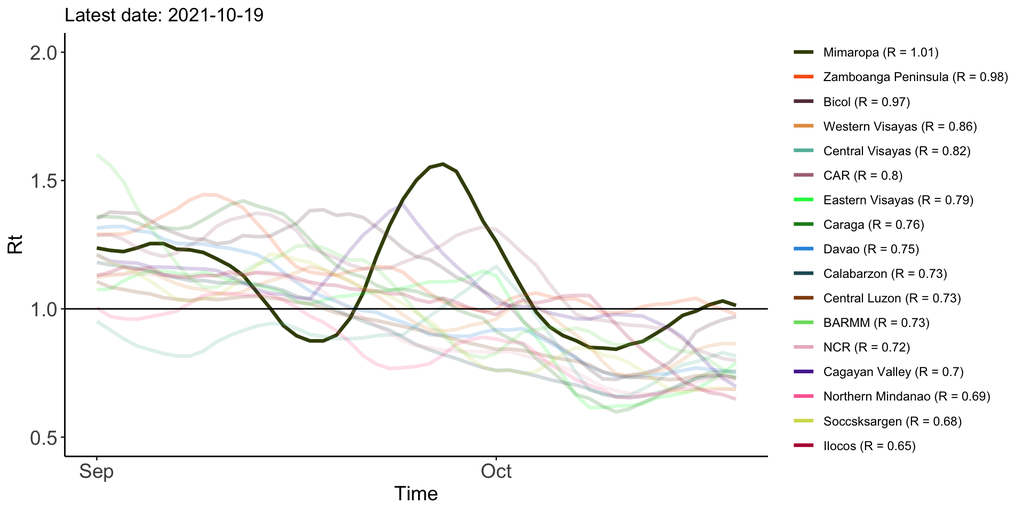

**Figure 4.** Mean effective reproductive number (**Rt**) of COVID-19 in the Philippines by region. The reproductive number (R) is defined as the number of new infections that one infected patient can cause in a susceptible population. Here, the mean effective reproductive number (Rt) was inferred by daily number of cases reported in MOH, Philippines in a window of seven days. The horizontal line indicates one. If Rt is greater than 1, the case number in the region will likely continue to grow. If the Rt is below 1, the new cases may continue appear but in a more slower rate. The R values denoted with the region name represent the most recent estimates.

$~$

## Philippines SARS-CoV-2 Phylotypes

$~$

[interactive chart not shown]

**Figure 5.** Phylogenetic relationships of phylotype (clusters) identified by [Grapevine-anywhere](https://github.com/GECO-PH/grapevine-anywhere). Each sequence submitted to GECO database would undergo *Grapevine-anywhere* pipeline to detect sustain local transmission. A cluster was defined based on multiple sequences isolated in the Philippines that appeared to descend from the same introductory event on a phylogenetic tree. A “PH_” here indicates sequences isolated by GECO without a assigned phylotype name.

$~$

## SARS-CoV-2 mutaions of interest

Spike protein

- **E484K:** [Distribution on the Philippine isolates](https://nextstrain.org/community/boydorr/GECO-covid@main/20211101?c=gt-S_484&f_country=Philippines&gt=S.484K)
- **D614G:** [Distribution on the Philippine isolates](https://nextstrain.org/community/boydorr/GECO-covid@main/20211101?c=gt-S_614&f_country=Philippines&gt=S.484K,614G)

$~$

### Data resources

1. [GECO website](https://www.geco-seqlab.org)
2. [DOH Data drop](https://drive.google.com/drive/folders/1ZPPcVU4M7T-dtRyUceb0pMAd8ickYf8o)
3. [GISAID](http://gisaid.org)
4. [Nextstrain](https://nextstrain.org)
5. [WHO variant](https://www.who.int/en/activities/tracking-SARS-CoV-2-variants/)
6. [Pango lineage](https://cov-lineages.org/lineage_list.html)

$~$